# Bayesian data analysis - BRMS demos

Posterior predictive checking with kernel density estimates for the data and 10 posterior predictive replicates looks good (although with this many parameters, this check is likely to be optimistic).

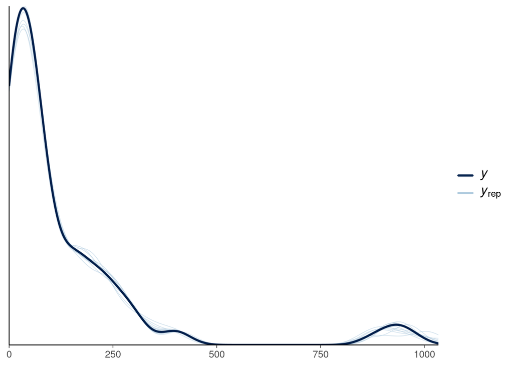

```r
pp_check(fit_hier, type='dens_overlay')
```

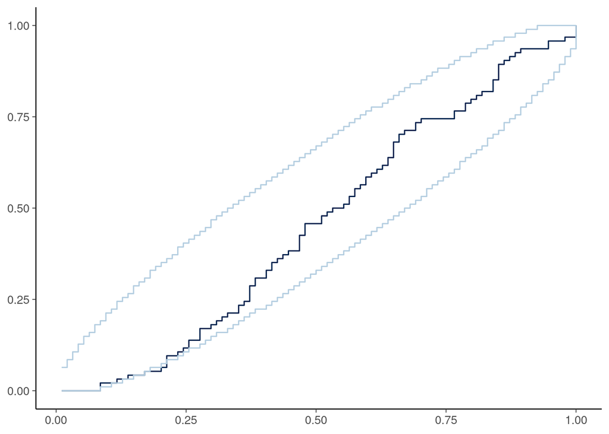

```r
pp_check(fit_hier, type='pit_ecdf', ndraws=4000)
```

Posterior predictive checking with LOO-PIT values look good (alhough as there are Pareto-khat warnings, it is possible that this diagnostic is optimistic).

```
Warning: Some Pareto k diagnostic values are too high. See help('pareto-k-diagnostic') for details.
```

```
Warning: Removed 2 rows containing missing values (`geom_point()`).
```

```
Warning: Removed 2 rows containing missing values (`geom_path()`).
```

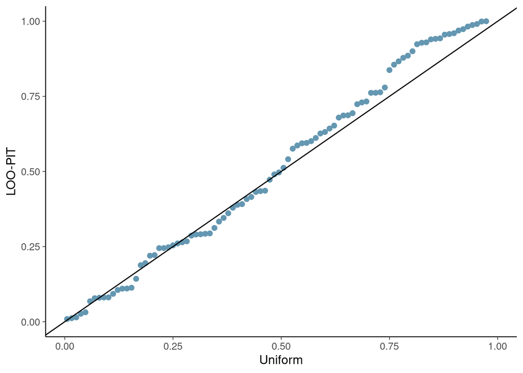

```r
pp_check(fit_hier, type='loo_pit_qq', ndraws=4000) +
  geom_abline() +
  ylim(c(0,1))
```

Treatment effect posteriors have now much less variation.

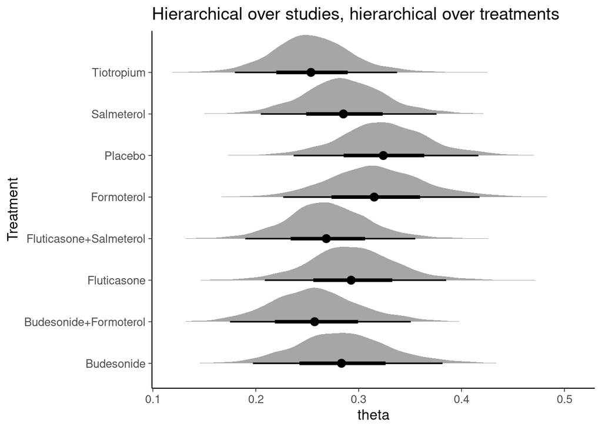

```r
fit_hier |>
  spread_rvars(b_Intercept, r_treatment[treatment,]) |>
  mutate(theta_treatment = rfun(plogis)(b_Intercept + r_treatment)) |>
  ggplot(aes(xdist=theta_treatment, y=treatment)) +
  stat_halfeye() +
  labs(x='theta', y='Treatment', title='Hierarchical over studies, hierarchical over treatments')
```

Study effect posteriors show the expected high variation.

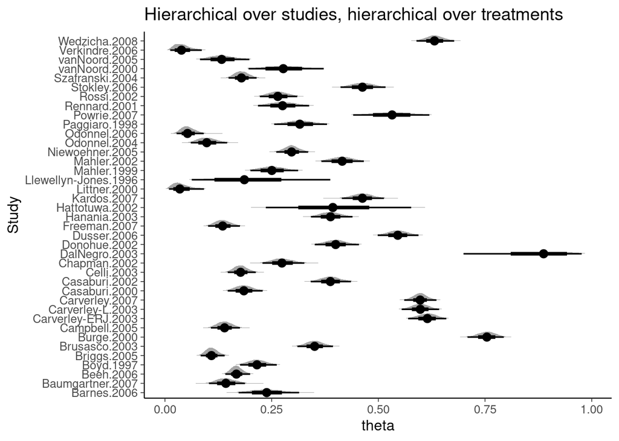

```r
fit_hier |>
  spread_rvars(b_Intercept, r_study[study,]) |>
  mutate(theta_study = rfun(plogis)(b_Intercept + r_study)) |>
  ggplot(aes(xdist=theta_study, y=study)) +
  stat_halfeye() +
  labs(x='theta', y='Study', title='Hierarchical over studies, hierarchical over treatments')
```

Treatment effect odds-ratio posteriors

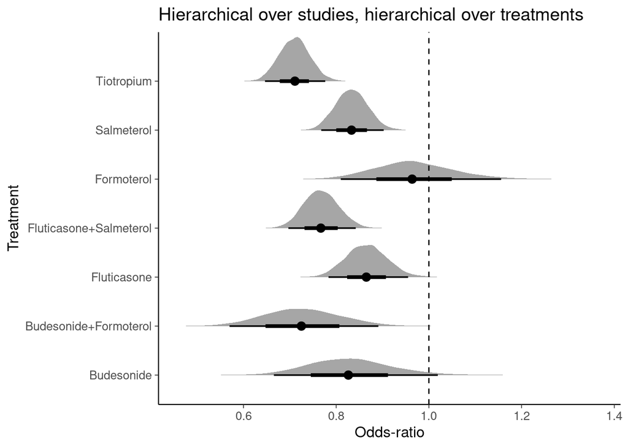

```r
theta <- fit_hier |>
  spread_rvars(b_Intercept, r_treatment[treatment,]) |>
  mutate(theta_treatment = rfun(plogis)(b_Intercept + r_treatment))
theta_placebo <- filter(theta,treatment=='Placebo')$theta_treatment[[1]]
theta |>
  mutate(treatment_oddsratio = (theta_treatment/(1-theta_treatment))/(theta_placebo/(1-theta_placebo))) |>
  filter(treatment != "Placebo") |>
  ggplot(aes(xdist=treatment_oddsratio, y=treatment)) +
  stat_halfeye() +
  labs(x='Odds-ratio', y='Treatment', title='Hierarchical over studies, hierarchical over treatments') +
  geom_vline(xintercept=1, linetype='dashed')
```

Treatment effect odds-ratios look now more reasonable. As now all treatments were compared to placebo, there is less overlap in the distributions as when looking at the thetas, as all thetas include similar uncertainty about the overall theta due to high variation between studies. The third model includes interaction so that the treatment can depend on study.

```r
fit_hier2 <- brm(exac | trials(total) ~ (1 | treatment) + (treatment | study),
                family=binomial(), data=dat.baker2009, control=list(adapt_delta=0.9))
```

```r
loo_compare(loo(fit_hier), loo(fit_hier2))
```

```
Warning: Found 18 observations with a pareto_k > 0.7 in model 'fit_hier'. It is
recommended to set 'moment_match = TRUE' in order to perform moment matching
for problematic observations.
```

```
Warning: Found 36 observations with a pareto_k > 0.7 in model 'fit_hier2'. It
is recommended to set 'moment_match = TRUE' in order to perform moment matching
for problematic observations.
```

```
          elpd_diff se_diff
fit_hier2  0.0       0.0
fit_hier  -1.1       2.8
```

# Licenses

- Code © 2017-2024, Aki Vehtari, licensed under BSD-3.
- Text © 2017-2024, Aki Vehtari, licensed under CC-BY-NC 4.0.